# Project

Srajan Rai- 19200436

8/3/2020

### Load the Libraries

```r
# Required Libraries
library(readr)
library(gganimate)
library(reshape2)
library(tidyr)
library(ggmap)
library(rstan)
library(dplyr)
library(magrittr)
library(ggplot2)
library(shiny)
library(lubridate)
library(shinystan)
library(ggiraph)
```

### Load the data set

```r
#Importing the data
data <- suppressWarnings(read_csv('exo_data.csv'))
```

## Part1

#### Import the dataset exo_data.csv as a tibble. Columns 1, 16, 17, 18, 25 should be characters. Columns 2, 14 should be factors. Column 15 should be integers. The remaining columns should be doubles.

#### We can see that the columns 1,16,17,18,25 are already characters,2,14 needs to be converted to factors and 15 is a number needs to be converted to a integer

```r
#Structure of the columns where  formatting needs to be done is checked
str(data[c(1,16,17,18,25,2,14,15)])
```

```
## tibble [3,659 × 8] (S3: tbl_df/tbl/data.frame)
##  $ id     : chr [1:3659] "KOI-1843.03" "Kepler-974 b" "KOI-1843.02" "Kepler-9 b" ...
##  $ recency: chr [1:3659] "13/07/15" "17/11/28" NA "15/12/03" ...
##  $ r_asc  : chr [1:3659] "19 00 03.14" "19 00 03.14" "19 00 03.14" "19 02 17" ...
##  $ decl   : chr [1:3659] "+40 13 14.7" "+40 13 14.7" "+40 13 14.7" "+38 24 03" ...
##  $ lists  : chr [1:3659] "Controversial" "Confirmed planets" "Controversial" "Confirmed planets" ...
##  $ flag   : num [1:3659] 0 0 0 0 0 0 0 0 0 0 ...
##  $ meth   : chr [1:3659] "transit" "transit" "transit" "transit" ...
##  $ year   : num [1:3659] 2012 NA NA 2010 2010 ...
##  - attr(*, "problems")= tibble [2 × 5] (S3: tbl_df/tbl/data.frame)
##   ..$ row     : int [1:2] 1712 2970
##   ..$ col     : chr [1:2] "age" "age"
##   ..$ expected: chr [1:2] "1/0/T/F/TRUE/FALSE" "1/0/T/F/TRUE/FALSE"
##   ..$ actual  : chr [1:2] "0.0055" "3.0"
##   ..$ file    : chr [1:2] "'exo_data.csv'" "'exo_data.csv'"
```

#### Columns flag and method are converted to factors and year to integer

```r
data$flag<-data$flag%>%as.factor
data$meth<-data$meth %>%as.factor

#Column 15 to integer
data$year<-data$year %>% as.integer
```

## Part2

#### Exclude the exoplanets with an unknown method of discovery.

#### Data is reduced from 3659 to 3596

```r
#Methods with na values are dropped from the data
data<-data %>% drop_na(meth)
```

## Part3

#### Create a graphic which illustrates the relationship between the log-distances from the Sun and the methods of discovery.

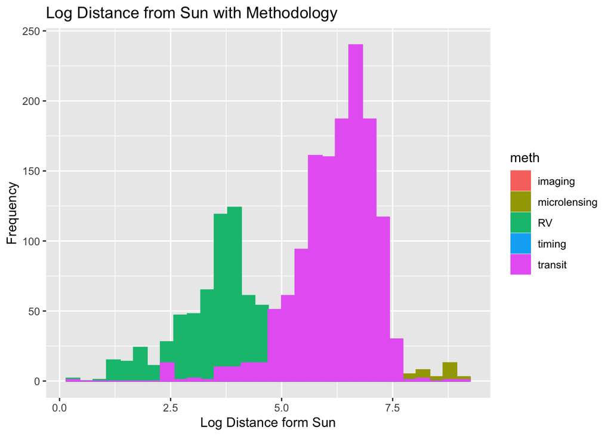

```r
#ggplot for log(distance), divided by colours by methods of discovery
ggplot(data, aes(x=log(dist), fill=meth, color=meth)) +
        geom_histogram(position="identity") +
        xlab('Log Distance form Sun')+
        ylab('Frequency')+
        ggtitle('Log Distance from Sun with Methodology')
```

## Part4

#### Create scatterplots of the log-mass versus log-distances, separating by methods of discovery. Hovering with the cursor highlights the point and displays its name, and, if you click, the exoplanet’s page on the Open Exoplanet Catalogue will be opened.

```r
#Used for the onclick event
data$onclick <- sprintf("window.open(\"%s%s\")",
                        "http://www.openexoplanetcatalogue.com/planet/",
                        data$id)
#ggplot of mass and distance
gg_graph = ggplot(data,
                  aes(x = log(mass),
                      y = log(dist),
                      color = meth)) +
                  xlab('log(mass)') +
                  ylab('log(distance') +
                  scale_color_discrete(name="Discovery Method")+
                  geom_point_interactive(aes(data_id = id,
                             tooltip = id,
                             onclick = onclick)) +
                  ggtitle("Scatterplots log-mass vs. log-distance")

ggiraph(code = print(gg_graph))
```

[interactive chart not shown]

## Part5

#### Rename the radius into jupiter_radius, and create a new column called earth_radius which is 11.2 times the Jupiter radius.

#### Using the pipe renaming and a new column has been added, rename function will do the renaming of the seleced column and mutate function is used to make the necessary trnasformation

```r
data <- data %>%
          rename(jupiter_radius = radius ) %>%
          mutate(earth_radius = jupiter_radius * 11.2 )
```

## Part6

#### Focus only on the rows where log-earth radius and log-period have no missing values, and perform kmeans with four clusters on these two columns.

#### A duplicate of original data is created then log of the required columns are taken the missing values are removed, the column for the analysis are selected

```r
#A duplicate of the original data is created for this part of the analysis
cluster_data <- data

#log-earth radius and log-period columns with missing data is removed
cluster_data <- cluster_data %>%
              mutate(logradius = log(earth_radius),
                             logperiod  = log(period))%>%
              drop_na(logradius, logperiod)



# 2 columns selected for the analysis
kmeans_data <- cluster_data %>%
               select(logradius,logperiod)
```

#### k-means with 4 clusters is performed on the kmeans_data, that has 2 columns

```r
#kmeans with 4 clusters
kmeanfit  <- kmeans(kmeans_data,centers =  4)
#Summary
summary(kmeanfit)
```

```
##              Length Class  Mode
## cluster      2732   -none- numeric
## centers         8   -none- numeric
## totss           1   -none- numeric
## withinss        4   -none- numeric
## tot.withinss    1   -none- numeric
## betweenss       1   -none- numeric
## size            4   -none- numeric
## iter            1   -none- numeric
## ifault          1   -none- numeric
```

## Part7

#### Add the clustering labels to the dataset through a new factor column called type, with levels rocky, hot_jupiters, cold_gas_giants, others;and produce the scatterplot highlighting these clusters.

#### New column of clusters is created with 4 levels and labelled as required

```r
kmeans_data$clusters<-factor(kmeanfit$cluster,levels = 1:4,labels =        c('hot_jupiters','others','rocky','cold_gas_giants'))
```

#### Scatter plot is created highlighting the clusters

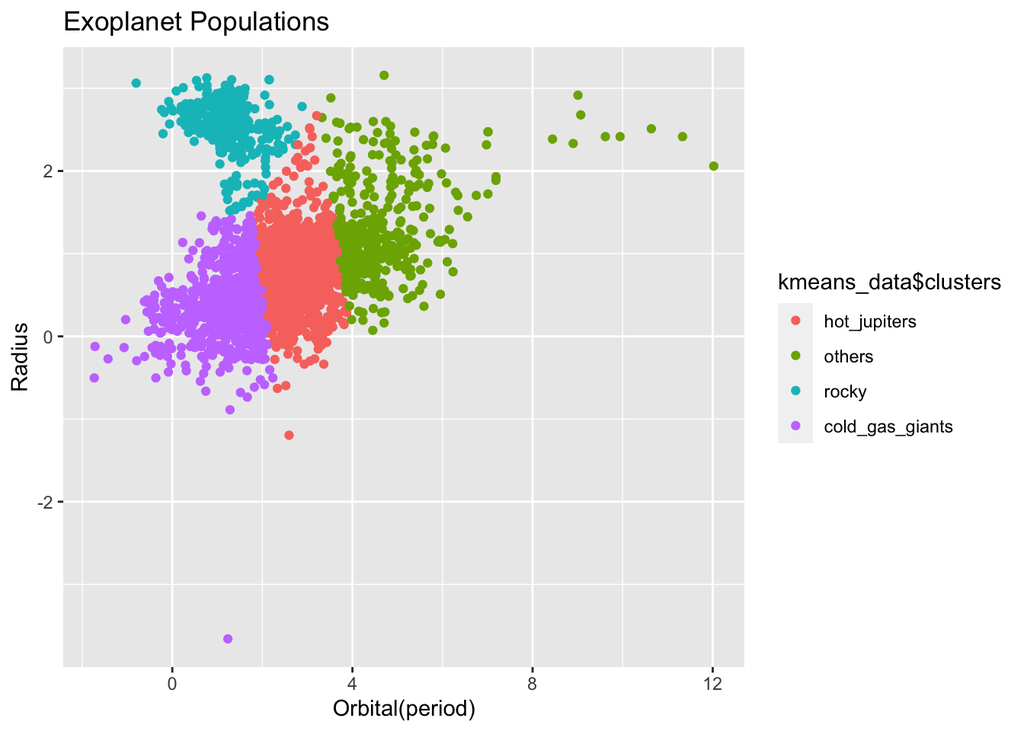

```r
cluster_data$type<-kmeans_data$clusters
ggplot(kmeans_data, aes(logperiod,logradius ,
                        color = kmeans_data$clusters)) +
                    geom_point()+
                    xlab('Orbital(period)')+
                    ylab('Radius')+
                    ggtitle("Exoplanet Populations")
```

## Part8

#### Use a violin plot to illustrate how these clusters relate to the log-mass of the exo- planet.

#### From the cluster_data, mass variables is added to the kmeans_data for the visualisation

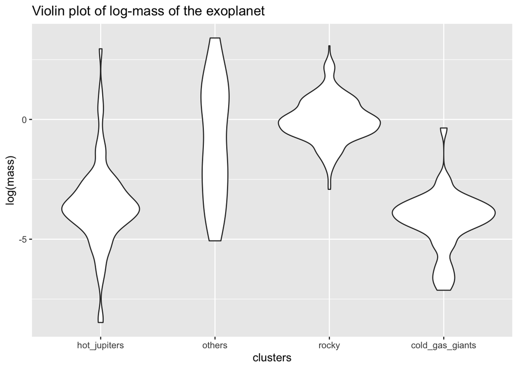

```r
#data is used for ggplot
kmeans_data$mass<-cluster_data$mass
#data is used for shiny app
cluster_data$type<-kmeans_data$clusters
#Violin plot using ggplot
ggplot(kmeans_data, aes(x = clusters, y = log(mass))) +
                    geom_violin() +
                    labs(title="Violin plot of log-mass of the exoplanet")
```

## Part9

#### Transform r_asc and decl into two new variables that are the same varibales but in values of seconds. Use these as coordinates to represent a celestial map for the exoplanets

#### The data is first brought into the required format, then converted into seconds

```r
# r_asc converted to hh:mm:ss format and converted to seconds stored in a new variable
data$r_asc_sec <- gsub(" ", ":", data$r_asc, fixed=TRUE)
# convert to hh:mm:ss
data$r_asc_sec <- hms(data$r_asc_sec)
data$r_asc_sec <- period_to_seconds(data$r_asc_sec)


# decl converted to dd:mm:ss format and converted to seconds stored in a new variable
data$decl_sec<- gsub(" ", ":", data$decl, fixed=TRUE) # convert to dd:mm:ss
data$decl_sec <- hms(data$decl_sec)
data$decl_sec <- period_to_seconds(data$decl_sec)
```

#### r_asc and declinations are used as coordinates to represent a celestial map for the exoplanets, scatter plot is used for the representations

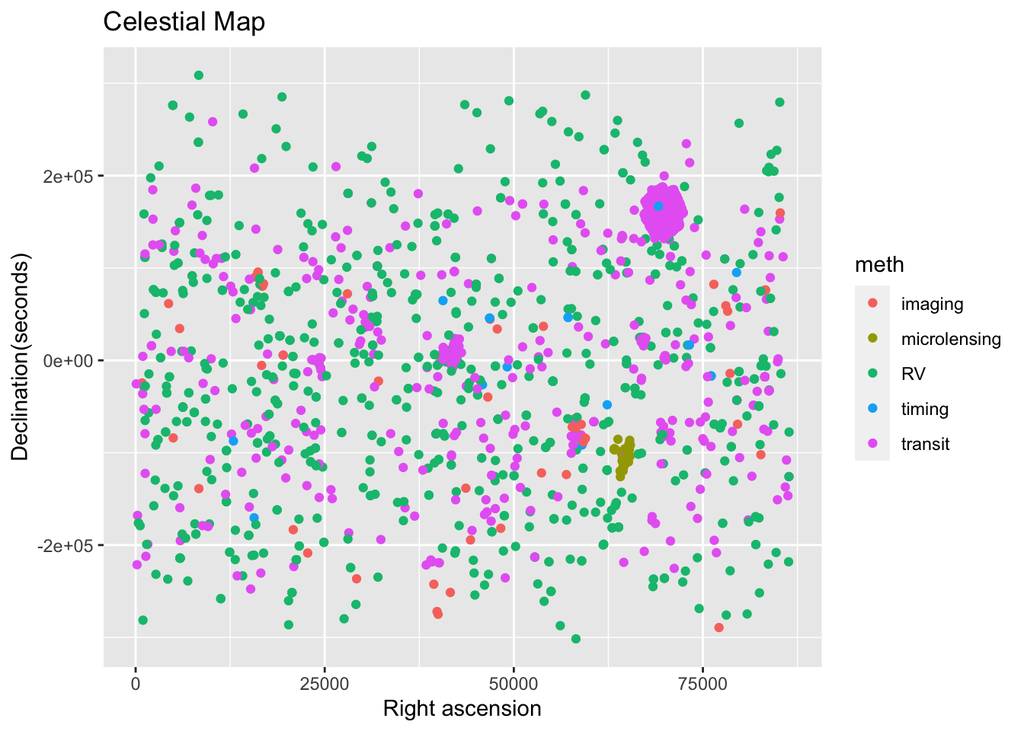

```r
##ggplot
ggplot(data, aes(r_asc_sec, decl_sec, color= meth)) +
                            geom_point() +
                            xlab('Right ascension')+
                            ylab('Declination(seconds)')+
                            ggtitle('Celestial Map ')
```

## Part10

#### Create an animated time series where multiple lines illustrate the evolution over time of the total number of exoplanets discovered for each method up to that year.

```r
# pipe line is used to first group then based on length of methods of discovery and mutated
time.data <- data %>% group_by(meth, year) %>%
                    summarise(Count =  length(meth)) %>%
                    mutate(Count = cumsum(Count))
```

[figure not shown]

```r
#NA values are removed
time.data <- na.omit(time.data)

#ggplot
ggplot(time.data, aes(x = year, y = Count, group = meth)) +
                geom_line(aes(color = meth)) +
                geom_point(size = 2) +
                transition_reveal(year) +
               ylab('Count of Discovered')+
               ggtitle('Total number of exoplanets discovered for each method')
```

## Question11

#### Create an interactive plot with Shiny where you can select the year (slider widget, with values ≥ 2009) and exoplanet type. Exoplanets appear as points on a scatter- plot (log-mass vs log-distance coloured by method) only if they have already been discovered. If type is equal to all all types are plotted together.

```r
# By setting echo to False, the code will not be visible on running the application just the things we want the user to be displayed will be visible
# In section 14, we have implemented the same
shinyApp(
ui <- fluidPage(


            sliderInput("slider1",
                        "Select Year", min=2009,
                        max(cluster_data$year,na.rm = TRUE),max(cluster_data$year,na.rm = TRUE),
                        round = TRUE, sep = '', width = '100%',step = 1,ticks = FALSE)
        ,
        selectInput(inputId = "exo_type",
                    label = "Type",
                    choices = c('hot_jupiters','rocky','cold_gas_giants','others',"all"),
                    selected = 0),





        # Show a plot of the generated distribution

plotOutput("scatter1",height = 300,width = 600)


),

# Define server logic required to draw a histogram
server <- function(input, output) {

  #organize data, only include planets with known mass



    #create scatterplot of all year's discoveries for selected years
    #
    output$scatter1 = renderPlot({
      if(input$exo_type=="all")
      {
        scatter1data<-cluster_data %>%filter(., year <= input$slider1, !is.na(mass),
                                     !is.na(dist))
      }
      else
      {
        scatter1data<-cluster_data %>%filter(., year <= input$slider1, !is.na(mass),
                                     !is.na(dist)) %>% filter(., type== input$exo_type)
      }


        ggplot(scatter1data, aes(x = log(dist), y = log(mass),
                                 color = meth)) +
            geom_point(size = 3) +
            labs(title = paste("Discoveries Through", input$slider1),
                 x = "Distance of Exoplanet Star from Sun (Parsecs)",
                 y = "Planet Mass (Jupiter Masses)",
                 colour = NULL)

    })

},
options = list(height = 550)

)
```

Shiny applications not supported in static R Markdown documents

## Part 12

#### Fit a linear regression model where log period is the response variable and the logs of host_mass, host_temp and axis are the covariates (exclude rows that contain at least one missing value). Include an intercept term in the regression model.

```r
#A new data is created  with required variables for the regression analysis
regdata <- data[,c("period","host_mass","host_temp","axis")]
#Data with missing values are omitted
regdata.complete <- na.omit(regdata)
#We fit the linear model
fit<-lm(log(period)~log(host_mass)+log(host_temp)+log(axis),data = regdata)
summary(fit)
```

```
##
## Call:
## lm(formula = log(period) ~ log(host_mass) + log(host_temp) +
##     log(axis), data = regdata)
##
## Residuals:
##     Min      1Q  Median      3Q     Max
## -2.0816 -0.0278 -0.0016  0.0277  3.4084
##
## Coefficients:
##                Estimate Std. Error t value Pr(>|t|)
## (Intercept)     5.66955    0.28995  19.554   <2e-16 ***
## log(host_mass) -0.40971    0.01596 -25.679   <2e-16 ***
## log(host_temp)  0.02462    0.03387   0.727    0.467
## log(axis)       1.48749    0.00365 407.555   <2e-16 ***
## ---
## Signif. codes:  0 '***' 0.001 '**' 0.01 '*' 0.05 '.' 0.1 ' ' 1
##
## Residual standard error: 0.2148 on 1263 degrees of freedom
##   (2329 observations deleted due to missingness)
## Multiple R-squared:  0.9929, Adjusted R-squared:  0.9929
## F-statistic: 5.862e+04 on 3 and 1263 DF,  p-value: < 2.2e-16
```

## Part 14

Shiny applications not supported in static R Markdown documents